# Machine Learning Project - Classification

Nuray Nasib

## Participants

- Nuray Nasib - 415708

## Introduction

The study would seek to determine how grades are influenced or appear to be with discrepancies in mathematics, reading and writing in: gender , race and ethinicity, parental level of education.

## Packages Required

```r
library(MASS)
library(dplyr)
library(rpart)
library(rpart.plot)
library(ggplot2)
library(randomForest)
library(class)
library(caTools)
library(caret)
library(tidyverse)
library(magrittr)
library(ggpubr)
library("e1071")
library(gmodels)

options(scipen = 100, max.print = 1e+06)
```

## Data & Data Preparation

```r
grades <- read_csv("StudentsPerformance.csv")
```

```r
rmarkdown::paged_table(grades)
```

| gender | race/ethnicity | parental level of education | lunch | test preparation course | math score | reading score | writing score |
| --- | --- | --- | --- | --- | --- | --- | --- |
| female | group B | bachelor's degree | standard | none | 72 | 72 | 74 |
| female | group C | some college | standard | completed | 69 | 90 | 88 |
| female | group B | master's degree | standard | none | 90 | 95 | 93 |
| male | group A | associate's degree | free/reduced | none | 47 | 57 | 44 |
| male | group C | some college | standard | none | 76 | 78 | 75 |
| female | group B | associate's degree | standard | none | 71 | 83 | 78 |
| female | group B | some college | standard | completed | 88 | 95 | 92 |
| male | group B | some college | free/reduced | none | 40 | 43 | 39 |
| male | group D | high school | free/reduced | completed | 64 | 64 | 67 |
| female | group B | high school | free/reduced | none | 38 | 60 | 50 |

[output cut: 990 more lines]

```r
#Count how many missing in every column
colSums(is.na(grades)) %>%
  sort()
```

```
##                      gender              race/ethnicity
##                           0                           0
## parental level of education                       lunch
##                           0                           0
##     test preparation course                  math score
##                           0                           0
##               reading score               writing score
##                           0                           0
```

```r
#Check if text
is.character(grades$gender)
```

```
## [1] TRUE
```

```r
#Convert gender from text to factors / it is nominal
grades$gender<-as.factor(grades$gender)

levels(grades$gender)
```

```
## [1] "female" "male"
```

```r
#Convert lunch from text to factors / it is nominal
grades$lunch<-as.factor(grades$lunch)

levels(grades$lunch)
```

```
## [1] "free/reduced" "standard"
```

```r
#Convert 'test preperation' from text to factors / it is nominal
grades$`test preparation course`<-as.factor(grades$`test preparation course`)

levels(grades$lunch)
```

```
## [1] "free/reduced" "standard"
```

```r
#Convert 'race ethnicity' from text to factors / it is nominal
grades$`race/ethnicity`<-as.factor(grades$`race/ethnicity`)

levels(grades$`race/ethnicity`)
```

```
## [1] "group A" "group B" "group C" "group D" "group E"
```

```r
is.factor(grades$`race/ethnicity`)
```

```
## [1] TRUE
```

```r
#Convert ordinal variable to factors/ 'parentel level education' is ordinal
is.character(grades$`parental level of education`)

table(grades$`parental level of education`)

levels(grades$`parental level of education`)

grades$`parental level of education`<- factor(grades$`parental level of education`,
                           # levels from lowest to highest
                           levels = c("some high school",
                                      "high school",
                                      "associate's degree",
                                      "some college",
                                      "bachelor's degree",
                                      "master's degree"),
                           ordered = TRUE) # ordinal

table(grades$`parental level of education`)
levels(grades$`parental level of education`)
glimpse(grades$`parental level of education`)

is.character(grades$`parental level of education`)
```

[output not shown]

```r
#Change Column names
colnames(grades)
```

```
## [1] "gender"                      "race/ethnicity"
## [3] "parental level of education" "lunch"
## [5] "test preparation course"     "math score"
## [7] "reading score"               "writing score"
```

```r
names(grades)[2]<-'race'
names(grades)[3]<-'parental.level.of.education'
names(grades)[5]<-'test.preparation.course'
names(grades)[6]<-'math.score'
names(grades)[7]<-'reading.score'
names(grades)[8]<-'writing.score'
```

my initial observations are; there are more females than males. Group C has the largest number of members. Some college and associate’s degree are the most frequently occuring parental levels of education. Most students have standard lunch. Most students haven’t completed test prep.

## Visualization

### First Visual

For the first visualization I want to see how the summary statistics for Math, Reading and Writing appear on a box plot and what these statistics look between genders.

```r
#Make copy of original df to allow dplyr manipulations
grades_copy=tbl_df(grades)

#Verify data frame is 'tbl_df' class type
class(grades_copy)

#Math box and whiskers plot
math_box=
  grades_copy %>%
    group_by(gender)%>%
    select(gender, math.score) %>%
    ggplot(aes(x=gender, y=math.score, col=gender )) +
    geom_boxplot() +
    ggtitle("Math Scores By Gender")+
    theme_linedraw()

#Reading box and whiskers
read_box=
  grades_copy%>%
    group_by(gender) %>%
    select(gender, reading.score) %>%
    ggplot(aes(x=gender, y=reading.score, col=gender)) +
    geom_boxplot() +
    ggtitle("Reading Scores By Gender")
    theme_linedraw()

#Writing box and whiskers
write_box=
  grades_copy %>%
    group_by(gender) %>%
    select(gender, writing.score) %>%
    ggplot(aes(x=gender, y=writing.score, col=gender)) +
    geom_boxplot() +
    ggtitle('Writing Scores By Gender') +
    theme_linedraw()
```

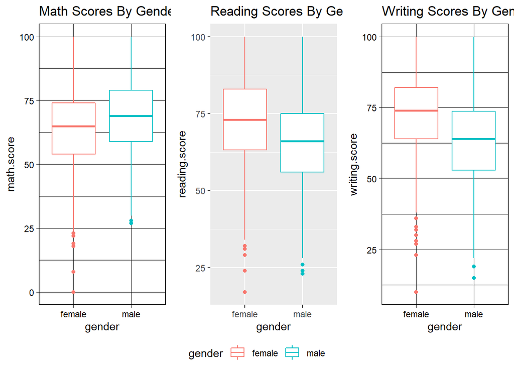

```r
#Putting all visualisiations together
ggarrange(math_box, read_box, write_box, common.legend = TRUE, legend = "bottom", nrow = 1, ncol = 3)
```

```r
#Table showing specific numbers in the graph below:

math_graph=
  grades_copy %>%
    group_by(gender) %>%
    select(gender, math.score) %>%
    summarise(count_gender = n(), avg_math = mean(math.score), median_math = median(math.score),
              min_math = min(math.score), max_math=max(math.score))

reading_graph=
  grades_copy %>%
  group_by(gender) %>%
  select(gender, reading.score) %>%
  summarise(count_gender = n(), avg_read = mean(reading.score), median_read = median(reading.score),
            min_read = min(reading.score), max_read=max(reading.score))


writing_graph=
  grades_copy %>%
  group_by(gender) %>%
  select(gender, writing.score) %>%
  summarise(count_gender = n(), avg_write = mean(writing.score), median_write = median(writing.score),
            min_write = min(writing.score), max_write=max(writing.score))
```

```r
math_graph
```

```
## # A tibble: 2 x 6
##   gender count_gender avg_math median_math min_math max_math
##   <fct>         <int>    <dbl>       <dbl>    <dbl>    <dbl>
## 1 female          518     63.6          65        0      100
## 2 male            482     68.7          69       27      100
```

```r
reading_graph
```

```
## # A tibble: 2 x 6
##   gender count_gender avg_read median_read min_read max_read
##   <fct>         <int>    <dbl>       <dbl>    <dbl>    <dbl>
## 1 female          518     72.6          73       17      100
## 2 male            482     65.5          66       23      100
```

```r
writing_graph
```

```
## # A tibble: 2 x 6
##   gender count_gender avg_write median_write min_write max_write
##   <fct>         <int>     <dbl>        <dbl>     <dbl>     <dbl>
## 1 female          518      72.5           74        10       100
## 2 male            482      63.3           64        15       100
```

Here II can see that Males on average score higher than Females in math,but Females on average score higher in reading and writing than Males. I can also see that there are several outliers present, more of them specifically for Females.

### Second Visual

Next I would like to explore with a similar graph as above if taking the preparation_course actually had an impact on test scores and how that looks between males and females.

```r
#Math with Test Preparation
math_test_prep=
  grades_copy %>%
    group_by(gender) %>%
    select(gender, math.score, test.preparation.course) %>%
    ggplot(aes(x=gender, y=math.score, col=gender)) +
    geom_boxplot() +
    facet_wrap(~ test.preparation.course) +
    ggtitle("Math Scores by Gender w/o Test Prep") +
    theme_linedraw()

#Reading with Test Preparation
read_test_prep =
  grades_copy %>%
  group_by(gender) %>%
  select(gender, reading.score, test.preparation.course) %>%
  ggplot(aes(x=gender, y=reading.score, col=gender)) +
  geom_boxplot() +
  facet_wrap(~ test.preparation.course) +
  ggtitle("Reading Scores by Gender w/o Test Prep") +
  theme_linedraw()

#Writing with Test Preparation
write_test_prep=
  grades %>%
  group_by(gender) %>%
  select(gender,writing.score,test.preparation.course) %>%
  ggplot(aes(x= gender, y= writing.score, col= gender)) +
  geom_boxplot() +
  facet_wrap(~test.preparation.course)+
  ggtitle("Writing Scores by Gender w/o Test Prep")+
  theme_linedraw()
```

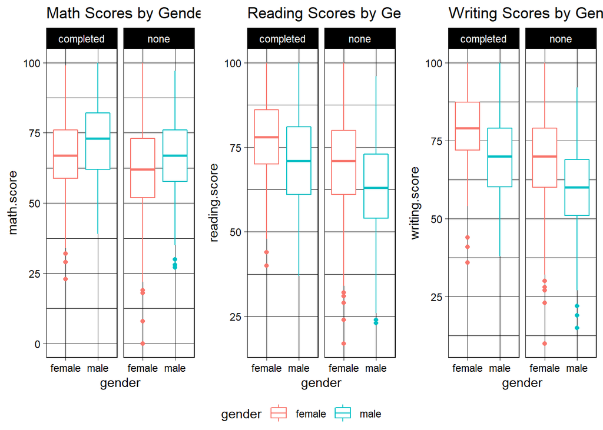

```r
ggarrange(math_test_prep, read_test_prep, write_test_prep, common.legend = TRUE, legend = 'bottom', nrow = 1, ncol = 3)
```

I will show the specific numbers behind each graph:

```r
# Math numbers in graph:
grades %>%
  group_by(test.preparation.course, gender) %>%
  select(test.preparation.course, gender, math.score) %>%
  summarise(count_gender= n(), avg_math= mean(math.score), median_math=median(math.score),
            min_math= min(math.score),max_math= max(math.score))
```

```
## # A tibble: 4 x 7
## # Groups:   test.preparation.course [2]
##   test.preparation.c~ gender count_gender avg_math median_math min_math max_math
##   <fct>               <fct>         <int>    <dbl>       <dbl>    <dbl>    <dbl>
## 1 completed           female          184     67.2          67       23       99
## 2 completed           male            174     72.3          73       39      100
## 3 none                female          334     61.7          62        0      100
## 4 none                male            308     66.7          67       27       97
```

```r
# Reading numbers in graph:
grades %>%
  group_by(test.preparation.course, gender) %>%
  select(test.preparation.course, gender, reading.score) %>%
  summarise(count_genders= n(),avg_read= mean(reading.score), median_read= median(reading.score),
            min_read= min(reading.score),max_read= max(reading.score))
```

```
## # A tibble: 4 x 7
## # Groups:   test.preparation.course [2]
##   test.preparation.~ gender count_genders avg_read median_read min_read max_read
##   <fct>              <fct>          <int>    <dbl>       <dbl>    <dbl>    <dbl>
## 1 completed          female           184     77.4          78       40      100
## 2 completed          male             174     70.2          71       37      100
## 3 none               female           334     70.0          71       17      100
## 4 none               male             308     62.8          63       23       96
```

```r
# Writing numbers in graph:
grades %>%
  group_by(test.preparation.course, gender) %>%
  select(test.preparation.course, gender, writing.score) %>%
  summarise(count_genders= n(),avg_write= mean(writing.score),median_write= median(writing.score),
            min_write= min(writing.score),max_write= max(writing.score))
```

```
## # A tibble: 4 x 7
## # Groups:   test.preparation.course [2]
##   test.preparation.course gender count_genders avg_write median_write min_write
##   <fct>                   <fct>          <int>     <dbl>        <dbl>     <dbl>
## 1 completed               female           184      78.8           79        36
## 2 completed               male             174      69.8           70        38
## 3 none                    female           334      69.0           70        10
## 4 none                    male             308      59.6           60        15
## # ... with 1 more variable: max_write <dbl>
```

By Looking at this graph I can see that the students who completed the test prepraration did in fact get higher scores than those students who didn’t take it. But interestingly enough I can see that for reading and writing scores, even when the males took the test prep course, they still performed almost equally as same as females who didnt take test prep course. And even with test preparation being in the picture females still outperformed males in both reading and writing. And in math males who didnt take test prep course almost did as well as the females who took the course.

### Third Visual

This next visualization is going to show how the scores appear between students who completed/not completed the test prep course for Math, Reading and Writing by different Race/Ethnicity groups, in a histogram format.

Each bar is representing a race(x-axis), and height of each bar shows the AVERAGE SCORE in Math, Reading and Writing.

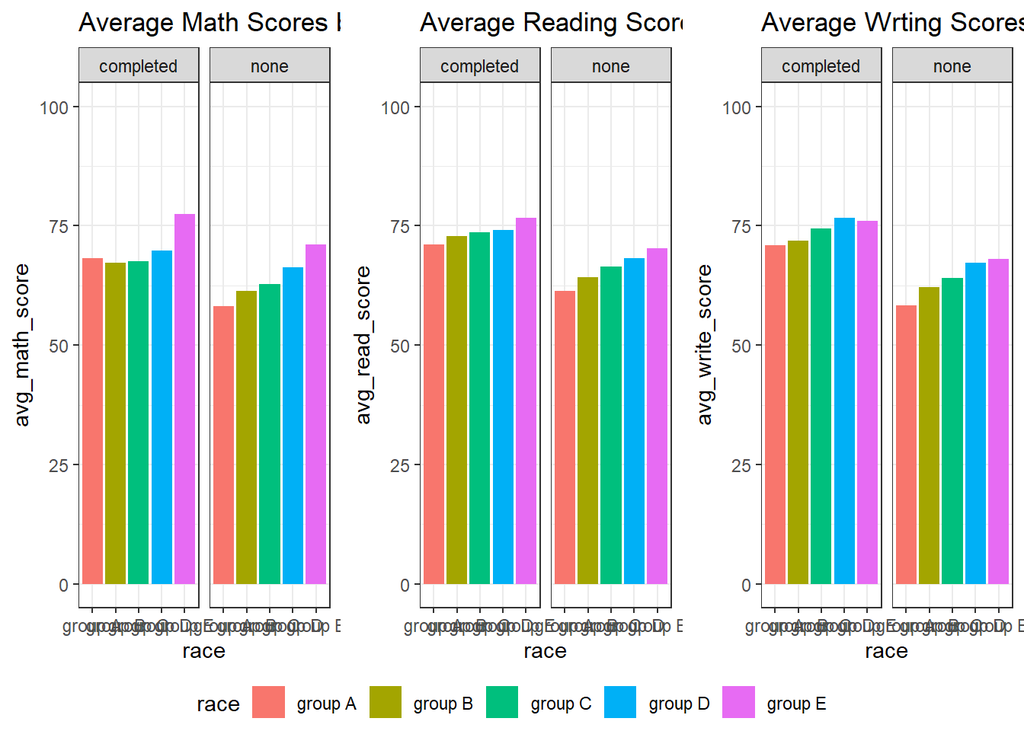

```r
avg_math_perRace =
  grades_copy %>%
  group_by(race, test.preparation.course) %>%
  select(race, math.score, test.preparation.course ) %>%
  summarise(avg_math_score=mean(math.score)) %>%
  ggplot(aes(x=race, y=avg_math_score, fill=race)) +
  ylim(0,100) +
  geom_col() +
  facet_wrap(~test.preparation.course) +
  ggtitle("Average Math Scores by Race") +
  theme_bw()
avg_read_perRace=
  grades_copy %>%
  group_by(race,test.preparation.course) %>%
  select(race, reading.score, test.preparation.course) %>%
  summarise(avg_read_score= mean(reading.score))%>%
  ggplot(aes(x= race, y= avg_read_score, fill= race))+
  ylim(0,100)+
  geom_col()+
  facet_wrap(~test.preparation.course)+
  ggtitle("Average Reading Scores by Race")+
  theme_bw()
avg_write_perRace=
  grades_copy %>%
  group_by(race,test.preparation.course) %>%
  select(race, writing.score, test.preparation.course) %>%
  summarise(avg_write_score= mean(writing.score))%>%
  ggplot(aes(x= race, y= avg_write_score, fill= race))+
  ylim(0,100)+
  geom_col()+
  facet_wrap(~test.preparation.course)+
  ggtitle("Average Wrting Scores by Race/Ethinicity")+
  theme_bw()
ggarrange(avg_math_perRace,avg_read_perRace,avg_write_perRace,common.legend = TRUE,
          legend = "bottom",nrow = 1, ncol = 3)
```

I will show the specific numbers behind each graph:

```r
# Math numbers in graph:
grades_copy %>%
  group_by(test.preparation.course, race) %>%
  select(test.preparation.course, race, math.score) %>%
  summarise(count_race= n(), avg_math= mean(math.score))
```

```
## # A tibble: 10 x 4
## # Groups:   test.preparation.course [2]
##    test.preparation.course race    count_race avg_math
##    <fct>                   <fct>        <int>    <dbl>
##  1 completed               group A         31     68.3
##  2 completed               group B         68     67.2
##  3 completed               group C        117     67.5
##  4 completed               group D         82     69.8
##  5 completed               group E         60     77.4
##  6 none                    group A         58     58.1
##  7 none                    group B        122     61.4
##  8 none                    group C        202     62.7
##  9 none                    group D        180     66.3
## 10 none                    group E         80     71.1
```

```r
# Reading numbers in graph:
grades_copy %>%
  group_by(test.preparation.course, race) %>%
  select(test.preparation.course, race, reading.score) %>%
  summarise(count_race= n(), avg_read= mean(reading.score))
```

```
## # A tibble: 10 x 4
## # Groups:   test.preparation.course [2]
##    test.preparation.course race    count_race avg_read
##    <fct>                   <fct>        <int>    <dbl>
##  1 completed               group A         31     71.0
##  2 completed               group B         68     72.9
##  3 completed               group C        117     73.7
##  4 completed               group D         82     74.1
##  5 completed               group E         60     76.7
##  6 none                    group A         58     61.3
##  7 none                    group B        122     64.3
##  8 none                    group C        202     66.5
##  9 none                    group D        180     68.2
## 10 none                    group E         80     70.3
```

```r
# Writing numbers in graph:
grades_copy %>%
  group_by(test.preparation.course, race) %>%
  select(test.preparation.course, race, writing.score) %>%
  summarise(count_race= n(), avg_math= mean(writing.score))
```

```
## # A tibble: 10 x 4
## # Groups:   test.preparation.course [2]
##    test.preparation.course race    count_race avg_math
##    <fct>                   <fct>        <int>    <dbl>
##  1 completed               group A         31     70.9
##  2 completed               group B         68     71.9
##  3 completed               group C        117     74.5
##  4 completed               group D         82     76.7
##  5 completed               group E         60     76.0
##  6 none                    group A         58     58.3
##  7 none                    group B        122     62.1
##  8 none                    group C        202     64.0
##  9 none                    group D        180     67.2
## 10 none                    group E         80     68.0
```

By looking at the graph above I can see that the same holds true, that taking the test prep course indeed increases scores and that group E and D seem to be the ones with the highest scores across all races.

### Fourth Visual

I will create a scatterplot that places a student on a grid based on their score in reading and math. Then I will show for each parentel level of education, in acesding order, how each scatterplot changes.

[figure not shown]

```r
some_high_school =
  grades_copy %>%
  filter(parental.level.of.education == 'some high school') %>%
  ggplot(aes(x=reading.score, y=math.score, col=gender)) +
  geom_jitter() +
  ggtitle('Some High School')

high_school =
  grades_copy %>%
  filter(parental.level.of.education == 'high school') %>%
  ggplot(aes(x=reading.score, y= math.score, col=gender)) +
  geom_jitter() +
  ggtitle('High School')

some_college =
  grades_copy %>%
  filter(parental.level.of.education == 'some college') %>%
  ggplot(aes(x=reading.score, y=math.score, col=gender)) +
  geom_jitter() +
  ggtitle('Some College')

college =
  grades_copy %>%
  filter(parental.level.of.education == 'college') %>%
  ggplot(aes(x=reading.score, y=math.score, col=gender)) +
  geom_jitter() +
  ggtitle('College')

associates_degree=
  grades_copy %>%
  filter(parental.level.of.education == "associate's degree") %>%
  ggplot(aes(x= reading.score, y= math.score, col= gender))+
  geom_jitter()+
  ggtitle("Associate's Degree")

bachelors_degree=
  grades_copy %>%
  filter(parental.level.of.education == "bachelor's degree") %>%
  ggplot(aes(x= reading.score, y= math.score, col= gender))+
  geom_jitter()+
  ggtitle("Bachelor's Degree")

masters_degree=
  grades_copy %>%
  filter(parental.level.of.education == "master's degree") %>%
  ggplot(aes(x= reading.score, y= math.score, col= gender)) +
  geom_jitter()+
  ggtitle("Master's Degree")

#Shows each level of education in ascending order, each dot is a student and is based on reading and math scores.
ggarrange(some_high_school, high_school,some_college, college, associates_degree,
          bachelors_degree, masters_degree, common.legend = TRUE, legend = 'bottom', nrow = 1, ncol = 7)
```

Table to show the number of students in each parentel level of education:

```r
grades_copy %>%
  group_by(parental.level.of.education) %>%
  summarise(level_edu=n()) %>%
  arrange(desc(level_edu))
```

```
## # A tibble: 6 x 2
##   parental.level.of.education level_edu
##   <ord>                           <int>
## 1 some college                      226
## 2 associate's degree                222
## 3 high school                       196
## 4 some high school                  179
## 5 bachelor's degree                 118
## 6 master's degree                    59
```

### Percentage Break

One Question is why have so many students who haven’t taken the prep courses if it really does help to improve the score of the tests. So lets dig deeper ‘none’ label students the assumption is that maybe the course is offered at a high cost and maybe the less priviledged students might not be able to afford it.

Below is the breakdown in percentages of students who did/did not take the test prep.

```r
percent_of_students = round(prop.table(table(grades_copy$test.preparation.course))*100, digits = 1)

percent_of_students
```

```
##
## completed      none
##      35.8      64.2
```

So 64.2% of students did not take the test prep course. Let’s look at the 64% in detail and see how this number breaks down by parental level of education.

```r
grades_copy %>%
  filter(test.preparation.course == 'completed') %>%
  group_by(parental.level.of.education) %>%
  summarise(students_count = n()) %>%
  arrange(desc(students_count))
```

```
## # A tibble: 6 x 2
##   parental.level.of.education students_count
##   <ord>                                <int>
## 1 associate's degree                      82
## 2 some high school                        77
## 3 some college                            77
## 4 high school                             56
## 5 bachelor's degree                       46
## 6 master's degree                         20
```

```r
grades_copy %>%
  filter(test.preparation.course == 'none') %>%
  group_by(parental.level.of.education) %>%
  summarise(students_count = n()) %>%
  arrange(desc(students_count))
```

```
## # A tibble: 6 x 2
##   parental.level.of.education students_count
##   <ord>                                <int>
## 1 some college                           149
## 2 high school                            140
## 3 associate's degree                     140
## 4 some high school                       102
## 5 bachelor's degree                       72
## 6 master's degree                         39
```

So I can still see some observations of student parents with advanced degrees.

Next lets look at how many of those students who have a free/reduced lunch in my 64% who did not take the course.

```r
grades_copy %>%
  filter(test.preparation.course == 'none') %>%
  filter(lunch == 'free/reduced') %>%
  group_by(parental.level.of.education) %>%
  summarise(students_counts_free_lunch = n()) %>%
  arrange(desc(students_counts_free_lunch))
```

```
## # A tibble: 6 x 2
##   parental.level.of.education students_counts_free_lunch
##   <ord>                                            <int>
## 1 some college                                        53
## 2 associate's degree                                  48
## 3 high school                                         46
## 4 some high school                                    38
## 5 bachelor's degree                                   27
## 6 master's degree                                     12
```

Let’s see in percentage:

```r
grades_copy %>%
  filter(test.preparation.course == 'none') %>%
  summarise(n())
```

[output not shown]

```r
some_college_perc = round(((53/642)*100),digits = 1)
associate_perc = round(((48/642)*100),digits = 1)
high_school_perc = round(((46/642)*100),digits = 1)
some_high_school_perc = round(((38/642)*100),digits = 1)
bachelors_perc = round(((27/642)*100),digits = 1)
masters_perc = round(((12/642)*100),digits = 1)

lunches_percents= c(some_college_perc,associate_perc,high_school_perc,some_high_school_perc,
                    bachelors_perc,masters_perc)

print(paste("some college percent=",lunches_percents[1],"%"))
```

```
## [1] "some college percent= 8.3 %"
```

```r
print(paste("assciate's  percent=",lunches_percents[2],"%"))
```

```
## [1] "assciate's  percent= 7.5 %"
```

```r
print(paste("high school percent =",lunches_percents[3],"%"))
```

```
## [1] "high school percent = 7.2 %"
```

```r
print(paste("some high school percent =",lunches_percents[4],"%"))
```

```
## [1] "some high school percent = 5.9 %"
```

```r
print(paste("bachelor's percent =",lunches_percents[5],"%"))
```

```
## [1] "bachelor's percent = 4.2 %"
```

```r
print(paste("masters percent =",lunches_percents[6],"%"))
```

```
## [1] "masters percent = 1.9 %"
```

With the assumption that income increases with level of education, (excluding bachelors = 4.2% and masters = 1.9%), approximately 28.9 % of students who did not take the test prep course have a potential excuse for not taking the course.

## Modeling & Evaluation

1. Single Decision Tree: it will build a simple decision tree
2. Random Forest Model: will create a Random Forest to see if this boosting technique improves my single decision tree model.

### Model 1: Single Decision Tree

```r
set.seed(1234)

#Partition data
index = createDataPartition(grades$test.preparation.course, p = 2/3, list=FALSE)

grades_train = grades[index, ]
grades_test = grades[-index, ]

print(paste("Training set observations: ", nrow(grades_train)))
```

```
## [1] "Training set observations:  667"
```

```r
print(paste("Test set observations: ", nrow(grades_test)))
```

```
## [1] "Test set observations:  333"
```

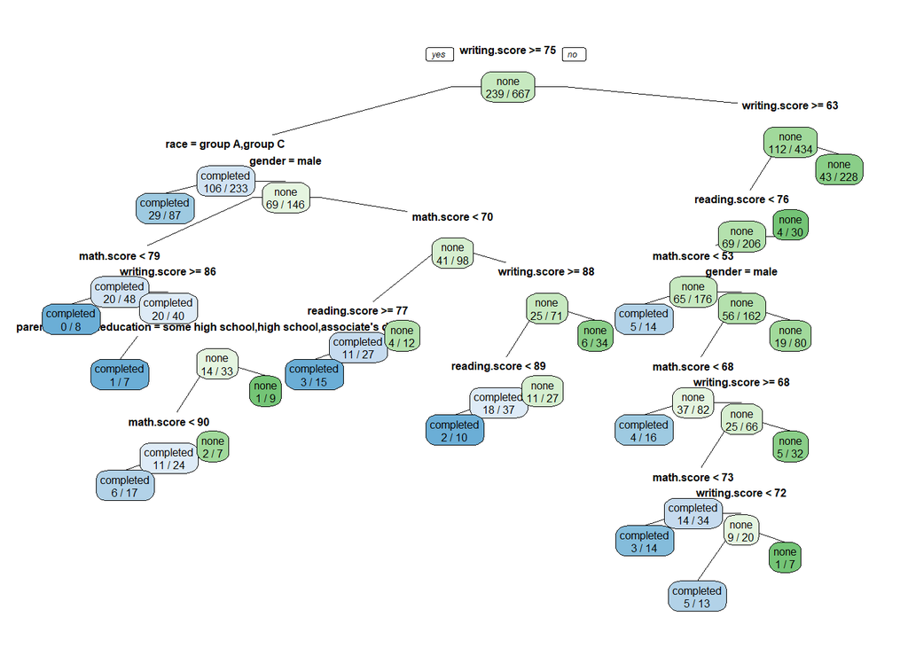

```r
single_decision_tree_model = rpart(test.preparation.course ~ ., method = "class", data = grades_train)
rpart.plot(single_decision_tree_model, type = 1, extra = 3, fallen.leaves = FALSE, clip.facs = FALSE,
           faclen=0, cex = 0.5, xlim=c(0,1), ylim=c(0,1))
```

By the looks of this tree, I can see that, it does not seem like good model, too long and hard to understand.

Evaluation of single decision tree:

```r
evaluation <- function(single_decision_tree_model, grades_train, atype) {

  cat("\nConfusion matrix:\n")
  prediction = predict(single_decision_tree_model, grades_train, type = atype)
  xtab = table(prediction, grades_train$test.preparation.course)
  print(xtab)
  cat("\nEvaluation:\n")
  accuracy = sum(prediction == grades_train$test.preparation.course)/length(grades_train$test.preparation.course)
  precision = xtab[1,1]/sum(xtab[,1])
  recall = xtab[1,1]/sum(xtab[1,])
  f=2*(precision * recall) / (precision + recall)
  cat(paste("Accuracy:\t", format(accuracy, digits = 2), "\n", sep=""))
  cat(paste("Precision:\t", format(precision, digits = 2), "\n", sep=""))
  cat(paste("Recall:\t\t", format(recall, digits = 2), "\n", sep=""))
  cat(paste("F-measure:\t", format(f, digits = 2), "\n", sep=""))
}

evaluation(single_decision_tree_model, grades_test, atype = "class")
```

```
##
## Confusion matrix:
##
## prediction  completed none
##   completed        58   40
##   none             61  174
##
## Evaluation:
## Accuracy:    0.7
## Precision:   0.49
## Recall:      0.59
## F-measure:   0.53
```

### Model 2: Random Forest

For this second model I will attempt to better the quality of my dataset with the goal of improving the accuracy of predicting whether a student took the prep course based on their testing scores. For this I will remove certain features (race.ethnicity, lunch, parental.level.of.education) and create a new data frame that will only have 4 features and leave the class variable as test.preparation.course.

Feature Reduction

```r
#New data frame for random forest model
grades2 = grades

drop = c("race", "parental.level.of.education", "lunch")

grades3 = grades2[,!(names(grades2) %in% drop)]

str(grades3)
```

```
## tibble[,5] [1,000 x 5] (S3: tbl_df/tbl/data.frame)
##  $ gender                 : Factor w/ 2 levels "female","male": 1 1 1 2 2 1 1 2 2 1 ...
##  $ test.preparation.course: Factor w/ 2 levels "completed","none": 2 1 2 2 2 2 1 2 1 2 ...
##  $ math.score             : num [1:1000] 72 69 90 47 76 71 88 40 64 38 ...
##  $ reading.score          : num [1:1000] 72 90 95 57 78 83 95 43 64 60 ...
##  $ writing.score          : num [1:1000] 74 88 93 44 75 78 92 39 67 50 ...
```

```r
#Remove outlier observations

#Here I will try to find a benchmark and remove any students from dataset that scored less than this benchmark.

summary(grades3$math.score)
```

```
##    Min. 1st Qu.  Median    Mean 3rd Qu.    Max.
##    0.00   57.00   66.00   66.09   77.00  100.00
```

```r
math_bench = 57 - 1.5 * IQR(grades3$math.score)

summary(grades3$reading.score)
```

```
##    Min. 1st Qu.  Median    Mean 3rd Qu.    Max.
##   17.00   59.00   70.00   69.17   79.00  100.00
```

```r
read_bench = 59 - 1.5 * IQR(grades3$reading.score)

summary(grades$writing.score)
```

```
##    Min. 1st Qu.  Median    Mean 3rd Qu.    Max.
##   10.00   57.75   69.00   68.05   79.00  100.00
```

```r
write_bench = 57.75 - 1.5 * IQR(grades3$writing.score)

print(paste("Math benchmark is: ", math_bench))
```

```
## [1] "Math benchmark is:  27"
```

```r
print(paste("Reading benchmark is: ", read_bench))
```

```
## [1] "Reading benchmark is:  29"
```

```r
print(paste("Writing benchmark is: ", write_bench))
```

```
## [1] "Writing benchmark is:  25.875"
```

```r
cleaned_grades =
  grades3 %>%
  filter(reading.score >= 29 ) %>%
  filter(math.score >= 27) %>%
  filter(writing.score >= 25.875) %>%
  select(gender : writing.score)

names(cleaned_grades)
```

```
## [1] "gender"                  "test.preparation.course"
## [3] "math.score"              "reading.score"
## [5] "writing.score"
```

```r
summary(cleaned_grades$reading.score)
```

```
##    Min. 1st Qu.  Median    Mean 3rd Qu.    Max.
##   29.00   60.00   70.00   69.64   80.00  100.00
```

```r
summary(cleaned_grades$writing.score)
```

```
##    Min. 1st Qu.  Median    Mean 3rd Qu.    Max.
##   27.00   58.00   69.00   68.57   79.00  100.00
```

```r
summary(cleaned_grades$math.score)
```

```
##    Min. 1st Qu.  Median    Mean 3rd Qu.    Max.
##   27.00   57.00   66.00   66.63   77.00  100.00
```

```r
print(paste("Data Frame with outliers: ",nrow(grades3)))
```

```
## [1] "Data Frame with outliers:  1000"
```

```r
print(paste("Data Frame w/o outliers: ",nrow(cleaned_grades)))
```

```
## [1] "Data Frame w/o outliers:  988"
```

```r
print(paste("Number of students removed: ", nrow(grades3)- nrow(cleaned_grades)))
```

```
## [1] "Number of students removed:  12"
```

I will re-do the data partitions using the new feature and outlier reduced dataframe “cleansed_grades”.

```r
index2= createDataPartition(cleaned_grades$test.preparation.course, p= 2/3, list= FALSE)

grades_train2= cleaned_grades[index2,]
grades_test2= cleaned_grades[-index2,]


str(grades_train2)
```

```
## tibble[,5] [659 x 5] (S3: tbl_df/tbl/data.frame)
##  $ gender                 : Factor w/ 2 levels "female","male": 1 2 2 1 2 1 2 1 1 2 ...
##  $ test.preparation.course: Factor w/ 2 levels "completed","none": 2 2 2 1 2 2 2 2 2 2 ...
##  $ math.score             : num [1:659] 72 47 76 88 40 38 40 65 69 88 ...
##  $ reading.score          : num [1:659] 72 57 78 95 43 60 52 81 75 89 ...
##  $ writing.score          : num [1:659] 74 44 75 92 39 50 43 73 78 86 ...
```

```r
str(grades_test2)
```

```
## tibble[,5] [329 x 5] (S3: tbl_df/tbl/data.frame)
##  $ gender                 : Factor w/ 2 levels "female","male": 1 1 1 2 2 2 1 1 2 2 ...
##  $ test.preparation.course: Factor w/ 2 levels "completed","none": 1 2 2 1 2 1 2 2 2 2 ...
##  $ math.score             : num [1:329] 69 90 71 64 58 78 50 54 73 69 ...
##  $ reading.score          : num [1:329] 90 95 83 64 54 72 53 58 74 54 ...
##  $ writing.score          : num [1:329] 88 93 78 67 52 70 58 61 72 55 ...
```

```r
Controlparameters = trainControl(method = 'cv', number = 5, savePredictions = TRUE, classProbs = TRUE)

#Specify mtry to build random forest --> will put this parameter in the model in the trControl argument.
parameter_grid = expand.grid(mtry = c(2,3,4))

random_forest_model = train(test.preparation.course ~., data = grades_train2, method = 'rf',
                            trControl = Controlparameters, tuneGrid = parameter_grid)

random_forest_model
```

```
## Random Forest
##
## 659 samples
##   4 predictor
##   2 classes: 'completed', 'none'
##
## No pre-processing
## Resampling: Cross-Validated (5 fold)
## Summary of sample sizes: 527, 526, 528, 527, 528
## Resampling results across tuning parameters:
##
##   mtry  Accuracy   Kappa
##   2     0.6524447  0.2062076
##   3     0.6478532  0.2049435
##   4     0.6417582  0.1917846
##
## Accuracy was used to select the optimal model using the largest value.
## The final value used for the model was mtry = 2.
```

Evaluation of Random Forest:

```r
rand_forest_predictions = predict(random_forest_model, grades_test2)
rand_forest_predictions
```

```
##   [1] completed none      none      completed none      completed completed
##   [8] none      none      none      none      none      none      completed
##  [15] none      none      completed none      none      none      none
##  [22] none      none      completed none      none      none      completed
##  [29] none      completed none      none      completed none      none
##  [36] none      completed none      none      completed completed none
##  [43] none      none      none      none      completed none      completed
##  [50] completed completed none      none      completed completed none
##  [57] completed completed none      completed completed none      completed
##  [64] none      completed none      completed none      completed completed
##  [71] none      completed none      none      none      none      completed
##  [78] none      completed none      none      completed completed none
##  [85] none      none      none      none      completed none      completed
##  [92] none      completed none      none      none      completed none
##  [99] completed none      completed completed none      none      none
```

[output cut: 33 more lines]

```r
rand_forest_table = table(predictions = rand_forest_predictions, actual = grades_test2$test.preparation.course)

rand_forest_table
```

```
##            actual
## predictions completed none
##   completed        62   49
##   none             57  161
```

```r
rf_test_accuracy = sum(diag(rand_forest_table) / sum(rand_forest_table))

print(paste("Random Forest accuracy: ", round(rf_test_accuracy*100), "%"))
```

```
## [1] "Random Forest accuracy:  68 %"
```

By the looks of this analysis I can conclude that this dataset may not be fitting well to this type of classification algorithm. Maybe using another classification method would help improve my results.

### Model 3: K-Nearest Neighbor Model

Based on the visualisation, where I plotted students in scotterplot based on their rading and math scores and by increasing parentel level of educaion. By looking at that graph I can see that, for the most part both males and females appear to be in similar groups when plotted based on reading and math scores, therefore I would like to build a KNN model to classify a student as either male or female based on their reading and math scores.

For this I will create a new data frame only containing gender, reading.score and math.score. And will remove these variable from the data frame I removed outliers from… cleaned_grades.

```r
#Create copy of original cleaned_grades data frame
cleaned_grades2 = cleaned_grades

#Remove all features except gender , reading score and math score
drop = c("test.preparation.course","writing.score")

cleaned_grades3 = cleaned_grades2[,!(names(cleaned_grades2) %in% drop)]

#Check the structure
str(cleaned_grades3)
```

```
## tibble[,3] [988 x 3] (S3: tbl_df/tbl/data.frame)
##  $ gender       : Factor w/ 2 levels "female","male": 1 1 1 2 2 1 1 2 2 1 ...
##  $ math.score   : num [1:988] 72 69 90 47 76 71 88 40 64 38 ...
##  $ reading.score: num [1:988] 72 90 95 57 78 83 95 43 64 60 ...
```

```r
#Check the class, if they are factors , continue
class(cleaned_grades3$gender)
```

```
## [1] "factor"
```

```r
#Will re-do data partitions once again with reduced feature data frame
index3= createDataPartition(cleaned_grades3$gender, p= 2/3, list= FALSE)

grades_train3= cleaned_grades3[index3,]
grades_test3= cleaned_grades3[-index3,]

#Check
str(grades_train3)
```

```
## tibble[,3] [659 x 3] (S3: tbl_df/tbl/data.frame)
##  $ gender       : Factor w/ 2 levels "female","male": 1 1 1 2 1 1 2 2 2 1 ...
##  $ math.score   : num [1:659] 72 69 90 76 71 88 40 64 40 65 ...
##  $ reading.score: num [1:659] 72 90 95 78 83 95 43 64 52 81 ...
```

```r
str(grades_test3)
```

```
## tibble[,3] [329 x 3] (S3: tbl_df/tbl/data.frame)
##  $ gender       : Factor w/ 2 levels "female","male": 2 1 2 1 1 1 1 1 2 2 ...
##  $ math.score   : num [1:329] 47 38 58 50 69 69 69 63 40 81 ...
##  $ reading.score: num [1:329] 57 60 54 53 75 73 74 65 42 81 ...
```

```r
# Will create 2 subsets of data frames for both the training and testing sets
# 2 subsets for training, one containing only the class labels and the other containing
# only the variables without the class labels.
grades_train3_wo_labels= subset(grades_train3, select= -gender)
grades_train3_w_labels= grades_train3$gender

# 2 subsets for testing one containing only the class labels
# and the other containing only the variables without the class label
grades_test3_wo_labels= subset(grades_test3, select= -gender)
grades_test3_w_labels= grades_test3$gender

print(paste("Best value for K, based on sqrt root of training set observations = ",
            sqrt(nrow(grades_train3))))
```

```
## [1] "Best value for K, based on sqrt root of training set observations =  25.6709953059869"
```

```r
# KNN model
knn_model = knn(train = grades_train3_wo_labels, test = grades_test3_wo_labels, cl = grades_train3_w_labels, k=25)

knn_model
```

```
##   [1] female female male   male   female female female male   male   male
##  [11] female male   female female female female female female female female
##  [21] male   male   female male   male   female female female male   male
##  [31] female male   male   male   female male   male   female female male
##  [41] male   male   male   female male   male   male   female female female
##  [51] female female male   male   male   female female female female male
##  [61] female male   male   male   female male   male   female female female
##  [71] male   male   male   male   male   male   female female female female
##  [81] male   male   female male   female female male   male   male   male
##  [91] male   male   male   female female male   male   female male   female
## [101] female male   male   female male   male   female female female female
## [111] male   female female female female female female male   female male
## [121] female female male   female female male   male   female female female
## [131] male   male   female female male   male   male   female male   male
## [141] male   male   male   male   female male   male   female male   female
```

[output cut: 19 more lines]

```r
# Evaluate models
knn_evaluation = CrossTable(x= grades_test3_w_labels, y= knn_model, prop.chisq= FALSE)
```

```
##
##
##    Cell Contents
## |-------------------------|
## |                       N |
## |           N / Row Total |
## |           N / Col Total |
## |         N / Table Total |
## |-------------------------|
##
##
## Total Observations in Table:  329
##
##
##                       | knn_model
## grades_test3_w_labels |    female |      male | Row Total |
## ----------------------|-----------|-----------|-----------|
##                female |       148 |        22 |       170 |
##                       |     0.871 |     0.129 |     0.517 |
##                       |     0.841 |     0.144 |           |
##                       |     0.450 |     0.067 |           |
## ----------------------|-----------|-----------|-----------|
##                  male |        28 |       131 |       159 |
##                       |     0.176 |     0.824 |     0.483 |
##                       |     0.159 |     0.856 |           |
##                       |     0.085 |     0.398 |           |
## ----------------------|-----------|-----------|-----------|
##          Column Total |       176 |       153 |       329 |
##                       |     0.535 |     0.465 |           |
## ----------------------|-----------|-----------|-----------|
##
##
```

```r
knn_model_accuracy= (141 + 130)/329

print(paste("KNN Model accuracy= ", round(knn_model_accuracy * 100), "%"))
```

[output not shown]

[output not shown]